# 95-868 Exercises Day 4

Reister L. Ruedas

Here are some libraries that you may need. (You may need to install the package `ggplot2movies`)

```r
library(ggplot2movies) # contains the movies dataset
library(ggplot2)
library(plyr)
library(reshape2)
library(Hmisc)
data("movies")
movies
```

```
## # A tibble: 58,788 x 24
##    title     year length budget rating votes    r1    r2    r3    r4    r5    r6
##    <chr>    <int>  <int>  <int>  <dbl> <int> <dbl> <dbl> <dbl> <dbl> <dbl> <dbl>
##  1 $         1971    121     NA    6.4   348   4.5   4.5   4.5   4.5  14.5  24.5
##  2 $1000 a~  1939     71     NA    6      20   0    14.5   4.5  24.5  14.5  14.5
##  3 $21 a D~  1941      7     NA    8.2     5   0     0     0     0     0    24.5
##  4 $40,000   1996     70     NA    8.2     6  14.5   0     0     0     0     0
##  5 $50,000~  1975     71     NA    3.4    17  24.5   4.5   0    14.5  14.5   4.5
##  6 $pent     2000     91     NA    4.3    45   4.5   4.5   4.5  14.5  14.5  14.5
##  7 $windle   2002     93     NA    5.3   200   4.5   0     4.5   4.5  24.5  24.5
##  8 '15'      2002     25     NA    6.7    24   4.5   4.5   4.5   4.5   4.5  14.5
##  9 '38       1987     97     NA    6.6    18   4.5   4.5   4.5   0     0     0
## 10 '49-'17   1917     61     NA    6      51   4.5   0     4.5   4.5   4.5  44.5
## # ... with 58,778 more rows, and 12 more variables: r7 <dbl>, r8 <dbl>,
## #   r9 <dbl>, r10 <dbl>, mpaa <chr>, Action <int>, Animation <int>,
## #   Comedy <int>, Drama <int>, Documentary <int>, Romance <int>, Short <int>
```

You shoud always 1. when plotting categorical data, consider whether the default ordering is best 2. label the axes and title, adjust the tick labels so they are legible, etc.

Note: For some reason my version of R started insisting that I use “summarise” (with the British spelling) instead of “summarize”. Not sure why!

Problem 1: Look at the `movies` dataset which comes with the `ggplot2movies` package. Make a bar chart that shows how many movies per year are in the data set, for the years 1900-1920.

Note: If you see a message that `binwidth defaulted to range/30`, then you are making a **histogram**, not a bar chart. Convert the `year` column to a factor to prevent this.

You will need to adjust the x axis labels so they are readable.

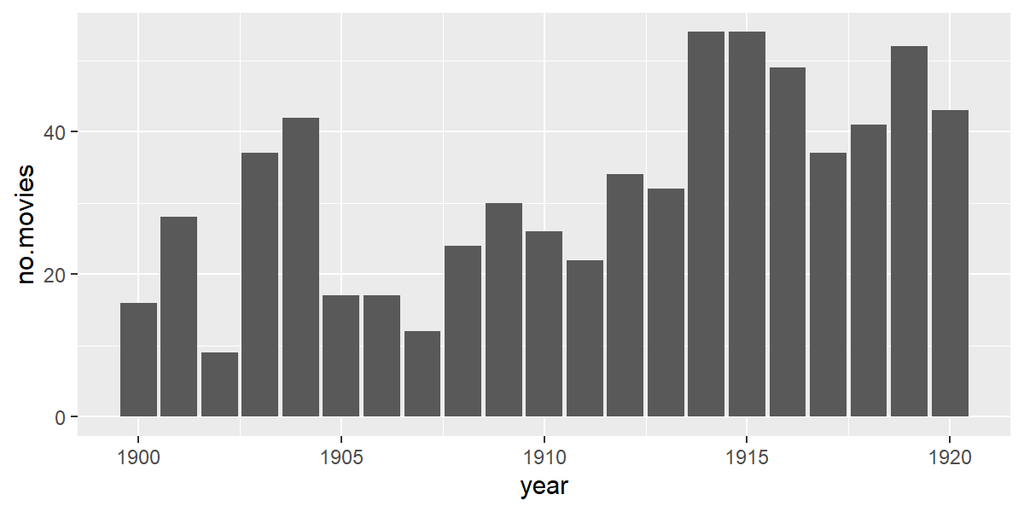

```r
# Add code and comments
newData = subset(movies, year >= 1900 & year <= 1920)
totals = ddply(newData, "year", summarise, no.movies = length(year))
ggplot(totals, aes(x = year, y = no.movies)) + geom_bar(stat="identity")
```

Problem 2: Create a dot chart that shows how many movies per year are in the data set, for all years. Use `stat_summary` with `fun.y=length` to do this.

Compare the difference when the `year` variable is treated as a factor or as a number. Which do you think makes the better plot?

```
## No summary function supplied, defaulting to `mean_se()`
```

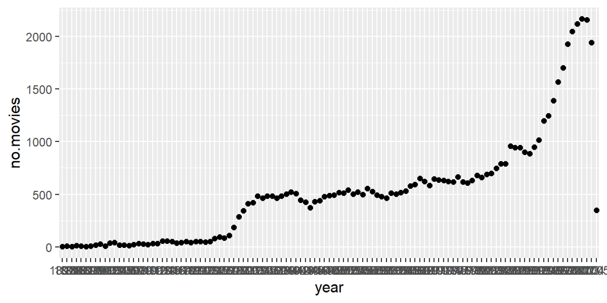

```r
# Add code and comments

total = ddply(movies, "year", summarise, no.movies = length(year))
total$year <- factor(total$year)

plot = ggplot(total, aes(x=year, y= no.movies )) + stat_summary(fun.x = length, geom = "point")
plot
```

Problem 3: Use the commands `stat_summary` and `geom_pointrange` to show the average ratings per year, +/- 95% confidence intervals, for all years. You can use the command `mean_cl_boot()` to compute the mean and CI’s automatically.

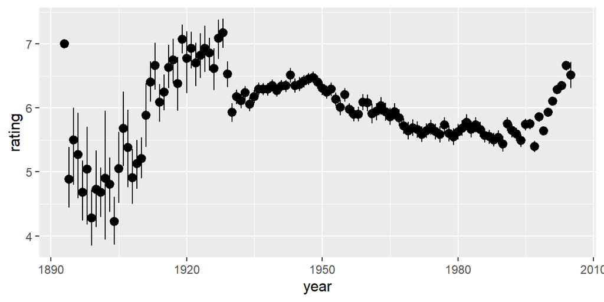

```r
# Add code and comments
ggplot(movies, mapping=aes(x=year, y=rating)) + stat_summary(fun.data = mean_cl_boot, geom='pointrange')
```

Problem 4a: Read the help page for `movies` to understand the meaning of each column. Create a line chart that shows the number of movies per year and per genre (Action, Animation, Comedy, Drama, Documentary, Romance, and Short). If a movie has multiple genres, then it should be counted in each one.

Hint: You can use the `melt()` command and then do a `subset()` to get the data into the form that you need.

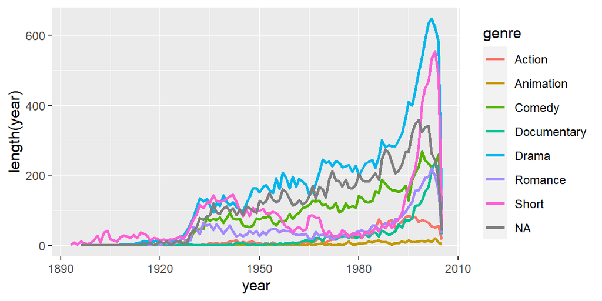

```r
# Add code and comments

genre <- rep(NA, ncol(movies))
genre[which(movies$Action == 1)] = "Action"
genre[which(movies$Animation == 1)] = "Animation"
genre[which(movies$Comedy == 1)] = "Comedy"
genre[which(movies$Drama == 1)] = "Drama"
genre[which(movies$Documentary == 1)] = "Documentary"
genre[which(movies$Romance == 1)] = "Romance"
genre[which(movies$Short == 1)] = "Short"
movies$genre<-as.factor(genre)

ggplot(movies, aes(x=year, y=length(year),colour=genre,group=genre)) + stat_summary(fun.y = length, geom="smooth")
```

Problem 4b: Remake the same plot, but as a stacked area chart. This is done by using `geom='area'`, and then `position='stack'`, inside the call to stat_summary. (you’ll also want to use `fill` instead of `color` most likely)

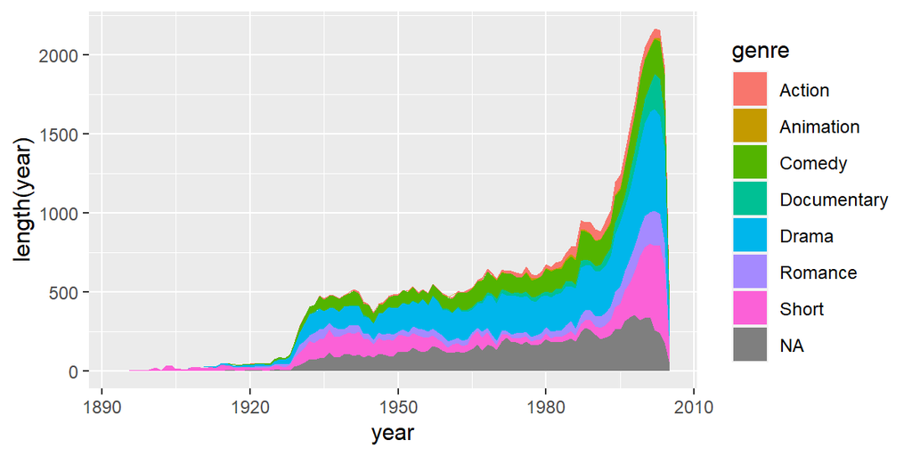

```r
# Add code and comments
ggplot(movies, aes(x=year, y=length(year),fill=genre,group=genre)) + stat_summary(fun.y = length, geom="area", position="stack")
```

Problem 5: Choose the 5 most common genres in the data set, and make a line chart showing the average ratings per year and genre.

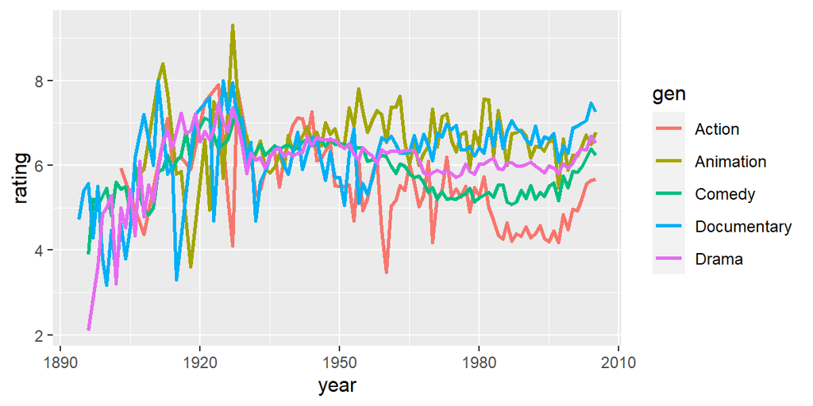

```r
# Add code and comments

genre <- rep(NA, ncol(movies))
genre[which(movies$Action == 1)] = "Action"
genre[which(movies$Animation == 1)] = "Animation"
genre[which(movies$Comedy == 1)] = "Comedy"
genre[which(movies$Drama == 1)] = "Drama"
genre[which(movies$Documentary == 1)] = "Documentary"
movies$gen<-as.factor(genre)
movies = subset(movies, !is.na(gen))

ggplot(movies, mapping=aes(x=year, y=rating, col = gen)) + stat_summary(fun.data = mean_cl_boot, geom='smooth')
```